# Results Memo: Grunfeld Investment Analysis

## What We Analyze

This memo summarizes a reproducible analysis of the `plm::Grunfeld` panel dataset. The analysis links firm investment to two firm-level measures: market value and capital stock. The sample contains 200 firm-year observations. An optional difference-in-differences example based on `AER::CardKrueger` is not included because that dataset was not available in this environment.

The goal is to describe the patterns clearly, not to make a causal claim. The main finding is that investment is strongly and positively associated with market value and capital stock in simple OLS models. The association remains positive in firm fixed-effects models, but it becomes smaller and statistically imprecise after adding both firm and year fixed effects or using lagged covariates.

## 1. Research Method And Regression Equations

The analysis uses a panel-data research design. Each observation is a firm-year, so the same firms are observed across multiple years. The outcome is logged investment. The main explanatory variable is logged market value, and logged capital stock is included as a control variable because investment is likely related to the productive capacity of the firm.

The first model is a pooled OLS regression. The bivariate version estimates the raw association between logged investment and logged market value, while the controlled version adds logged capital stock:

*log*(investment<sub>it</sub>) = α + β<sub>1</sub> *log*(market_value<sub>it</sub>) + β<sub>2</sub> *log*(capital_stock<sub>it</sub>) + ε<sub>it</sub>

The next models add firm fixed effects and then firm plus year fixed effects. Firm fixed effects control for time-invariant differences across firms, such as persistent size, management style, or industry position. Year fixed effects control for economy-wide shocks or common time trends that affect all firms in the same year:

*log*(investment<sub>it</sub>) = β<sub>1</sub> *log*(market_value<sub>it</sub>) + β<sub>2</sub> *log*(capital_stock<sub>it</sub>) + γ<sub>i</sub> + δ<sub>t</sub> + ε<sub>it</sub>

The lagged-covariate model keeps the firm and year fixed effects but uses one-year lagged market value and capital stock. This checks whether the result is similar when explanatory variables are measured before the investment outcome:

*log*(investment<sub>it</sub>) = β<sub>1</sub> *log*(market_value<sub>i,t-1</sub>) + β<sub>2</sub> *log*(capital_stock<sub>i,t-1</sub>) + γ<sub>i</sub> + δ<sub>t</sub> + ε<sub>it</sub>

The robustness model uses the same fixed-effects structure, but replaces the logged market value and logged capital stock variables with winsorized versions. This checks whether extreme covariate values are driving the results:

*log*(investment<sub>it</sub>) = β<sub>1</sub> winsorized_log_market_value<sub>it</sub> + β<sub>2</sub> winsorized_log_capital_stock<sub>it</sub> + γ<sub>i</sub> + δ<sub>t</sub> + ε<sub>it</sub>

In these equations, `i` indexes firms and `t` indexes years. The control variables are logged capital stock, firm fixed effects, and year fixed effects. The OLS model uses heteroskedasticity-robust standard errors, while the fixed-effects models use firm-clustered standard errors.

| Control variable | Included in | Purpose |
| --- | --- | --- |
| Logged capital stock | OLS, firm/year fixed effects, robustness | Controls for the firm’s productive capacity, which is likely related to investment. |
| Firm fixed effects | Firm/year fixed effects, robustness | Controls for time-invariant differences across firms. |
| Year fixed effects | Firm/year fixed effects, robustness | Controls for common shocks or trends affecting all firms in a given year. |

## 2. Correlations And Variable Relationships

Table 0. Correlation matrix for logged analysis variables

| Variable | Log investment | Log market value | Log capital stock |
| --- | --- | --- | --- |
| log_invest | 1.000 | 0.854 | 0.718 |
| log_value | 0.854 | 1.000 | 0.463 |
| log_capital | 0.718 | 0.463 | 1.000 |

Table 0 shows that logged investment is strongly correlated with logged market value (`0.854`) and also positively correlated with logged capital stock (`0.718`). Logged market value and logged capital stock have a more moderate correlation (`0.463`), which supports including both variables in the controlled models without treating them as duplicates.

## 3. Sample And Descriptive Patterns

Table 1. Summary statistics

| Variable | N | Mean | SD | Min | Max |
| --- | --- | --- | --- | --- | --- |
| Investment | 200 | 145.96 | 216.88 | 0.93 | 1486.70 |
| Market value | 200 | 1081.68 | 1314.47 | 58.12 | 6241.70 |
| Capital stock | 200 | 276.02 | 301.10 | 0.80 | 2226.30 |
| Log investment | 200 | 4.12 | 1.45 | -0.07 | 7.30 |
| Log market value | 200 | 6.28 | 1.24 | 4.06 | 8.74 |
| Log capital stock | 200 | 4.88 | 1.56 | -0.22 | 7.71 |

Table 1 establishes the scale and spread of the data. Average investment is 145.96, but the standard deviation is 216.88 and values range from 0.93 to 1,486.70. Market value and capital stock also vary widely: average market value is 1,081.68 with a standard deviation of 1,314.47, while average capital stock is 276.02 with a standard deviation of 301.10.

This large variation motivates the use of logged variables in the regression analysis. Logs make the distributions easier to compare and allow coefficients to be read approximately as percentage associations.

## 4. Visual Evidence

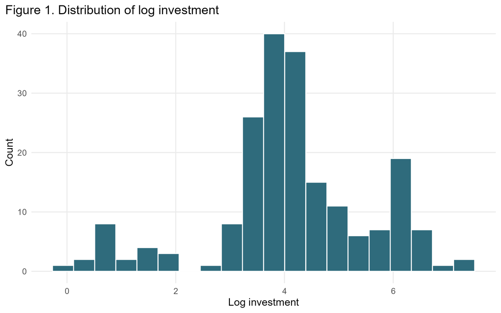

Figure 1. Distribution of log investment

Figure 1 shows the distribution of logged investment. This figure is useful because raw investment has a wide range, while the logged scale compresses very large values and makes the main mass of observations easier to inspect. The figure should be read as a descriptive check on the outcome variable before moving to relationships between variables.

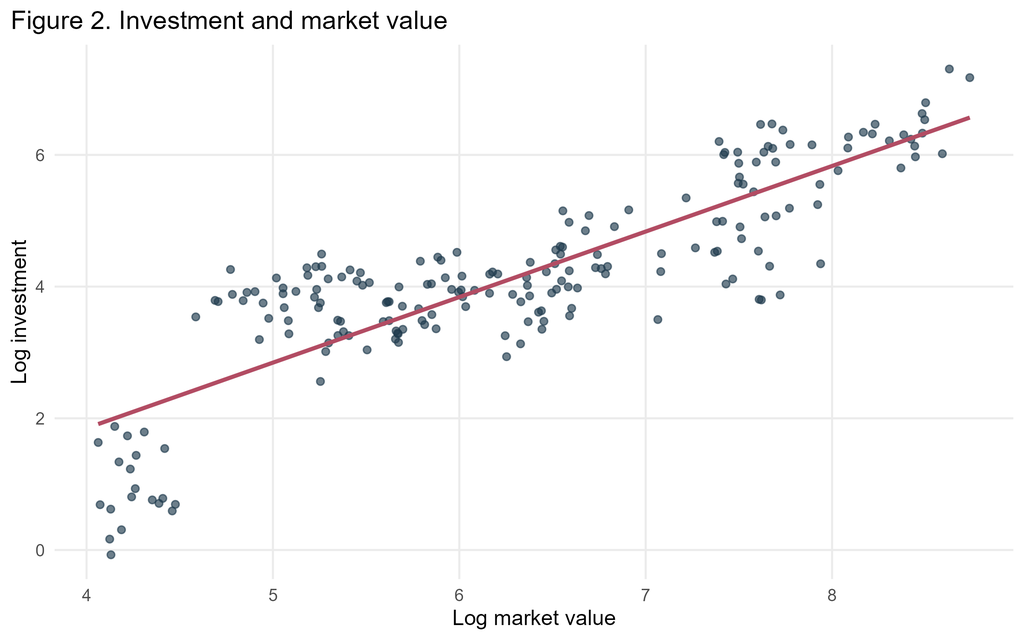

Figure 2. Investment and market value

Figure 2 presents the bivariate relationship between log market value and log investment. The fitted line slopes upward, showing a positive raw association: observations with higher market value generally have higher investment. This visual pattern supports the simple OLS results, but it does not by itself separate firm-specific differences, economy-wide year effects, or other confounding factors from the relationship of interest.

## 5. Main Regression Evidence

Table 2. Main Grunfeld results

OLS: bivariate

OLS: + capital control

Firm FE

Firm + Year FE

Lagged covariates FE

Log market value

0.995***

0.773***

0.592***

0.329

(0.052)

(0.042)

(0.127)

(0.186)

Log capital stock

0.381***

0.256***

0.077

(0.038)

(0.069)

(0.050)

Lagged log market value

0.125

(0.211)

Lagged log capital stock

0.033

(0.036)

Observations

200

200

200

200

190

R2

0.729

0.862

0.961

0.979

0.977

Adjusted R2

0.727

0.860

0.958

0.975

0.973

Capital control

No

Yes

Yes

Yes

Yes

Firm fixed effects

No

No

Yes

Yes

Yes

Year fixed effects

No

No

No

Yes

Yes

Lagged covariates

No

No

No

No

Yes

Standard errors in parentheses.

- p < 0.10, ** p < 0.05, *** p < 0.01.

OLS models use heteroskedasticity-robust standard errors; fixed-effects models use firm-clustered standard errors.

Table 2 now presents the regression results in a journal-style format with models as columns, coefficient stars, standard errors in parentheses, and rows that identify the controls and fixed effects. The bivariate OLS model estimates a strong positive association between log market value and log investment (`1.00`). After adding the log capital stock control, the market value estimate is smaller but remains large and positive (`0.77`), while log capital stock is also positive (`0.38`).

The firm fixed-effects model still shows positive and statistically significant estimates for market value (`0.59`) and capital stock (`0.26`). After adding year fixed effects, the estimates fall to `0.33` for market value and `0.08` for capital stock, and both become statistically imprecise. The lagged-covariate fixed-effects model is even more cautious: lagged market value is `0.13` and lagged capital stock is `0.03`, with neither estimate statistically distinguishable from zero.

The clearest interpretation is descriptive: firms or firm-years with higher market value and capital stock also tend to have higher investment. The fixed-effects results suggest caution before interpreting that relationship as causal.

## 6. Diagnostics And Specification Tests

Table 4. Model diagnostics and specification tests

| Model | N | R2 | Adj. R2 | Within R2 | Within Adj. R2 | Joint F-stat. | Joint p-value | BP-style stat. | BP-style p-value |
| --- | --- | --- | --- | --- | --- | --- | --- | --- | --- |
| OLS: bivariate | 200 | 0.729 | 0.727 | NA | NA | 373.00 | 0.00e+00 | 24.000 | 1.00e-06 |
| OLS: + capital control | 200 | 0.862 | 0.860 | NA | NA | 541.00 | 0.00e+00 | 0.506 | 4.77e-01 |
| Firm FE | 200 | 0.961 | 0.958 | 0.5640 | 0.56000 | 62.00 | 5.50e-06 | 21.100 | 4.30e-06 |
| Firm + Year FE | 200 | 0.979 | 0.975 | 0.1220 | 0.11200 | 7.32 | 1.30e-02 | 18.000 | 2.20e-05 |
| Lagged covariates FE | 190 | 0.977 | 0.973 | 0.0192 | 0.00697 | 1.13 | 3.65e-01 | 15.300 | 9.27e-05 |

Table 4 adds model diagnostics and tests. The joint regressor tests show that the market value and capital stock variables are jointly informative in the OLS, firm fixed-effects, and firm plus year fixed-effects models. The lagged-covariate model is not jointly significant, which reinforces the more cautious interpretation of the lagged specification. The Breusch-Pagan-style diagnostics indicate heteroskedasticity in several specifications, supporting the use of robust or clustered standard errors.

## 7. Robustness Check

Table A1. Robustness results

Winsorized FE

First differences

Winsorized log market value

0.330

(0.183)

Winsorized log capital stock

0.085

(0.057)

Delta log market value

0.579***

(0.070)

Delta log capital stock

-0.073**

(0.030)

Observations

200

190

R2

0.979

0.231

Adjusted R2

0.975

0.222

Capital control

Yes

Yes

Firm fixed effects

Yes

No

Year fixed effects

Yes

No

Specification

Winsorized covariates

Within-firm changes

Standard errors in parentheses.

- p < 0.10, ** p < 0.05, *** p < 0.01.

Standard errors are clustered by firm.

Table A1 reports two robustness checks. The winsorized fixed-effects model repeats the firm and year fixed-effects regression after winsorizing the logged market value and logged capital stock variables. This checks whether the fixed-effects pattern is driven by extreme logged covariate values. The first-difference model instead uses year-to-year changes within firms, which provides another way to focus on within-firm variation.

The winsorized estimates are close to the main fixed-effects estimates. The estimate for winsorized log market value is `0.33` with a p-value of `0.10`, and the estimate for winsorized log capital stock is `0.09` with a p-value of `0.17`. The first-difference model estimates a positive association for changes in market value (`0.58`) and a negative association for changes in capital stock (`-0.07`). Together, the robustness checks show that the positive market value relationship is visible in several specifications, but its strength and precision depend on how within-firm and time variation are modeled.